# R Markdown Demo

R. Burke Squires

2023-04-27

# Introduction

This is a simple demonstration of R Markdown’s capabilities. R Markdown allows you to write text using Markdown syntax, embed R code, and produce dynamic output in various formats.

# Markdown Formatting

## Headers

You can create headers using the `#` symbol:

# H1

## H2

### H3

## Text Formatting

You can create *italic text* using a single asterisk or underscore:

*Italic text* or *Italic text*

You can create **bold text** using double asterisks or underscores:

**Bold text** or **Bold text**

## Lists

You can create unordered lists using asterisks, plus signs, or hyphens:

- Item 1
- Item 2

You can create ordered lists using numbers followed by periods:

1. Item 1
2. Item 2

# R Code Chunks

You can embed R code chunks using three backticks followed by `{r}`:

```r
# Here's an example R code chunk
library(ggplot2)
data(mtcars)
head(mtcars)
```

```
##                    mpg cyl disp  hp drat    wt  qsec vs am gear carb
## Mazda RX4         21.0   6  160 110 3.90 2.620 16.46  0  1    4    4
## Mazda RX4 Wag     21.0   6  160 110 3.90 2.875 17.02  0  1    4    4
## Datsun 710        22.8   4  108  93 3.85 2.320 18.61  1  1    4    1
## Hornet 4 Drive    21.4   6  258 110 3.08 3.215 19.44  1  0    3    1
## Hornet Sportabout 18.7   8  360 175 3.15 3.440 17.02  0  0    3    2
## Valiant           18.1   6  225 105 2.76 3.460 20.22  1  0    3    1
```

# Plotting

You can also include plots in your R Markdown document. Here’s a scatter plot using the `mtcars` dataset:

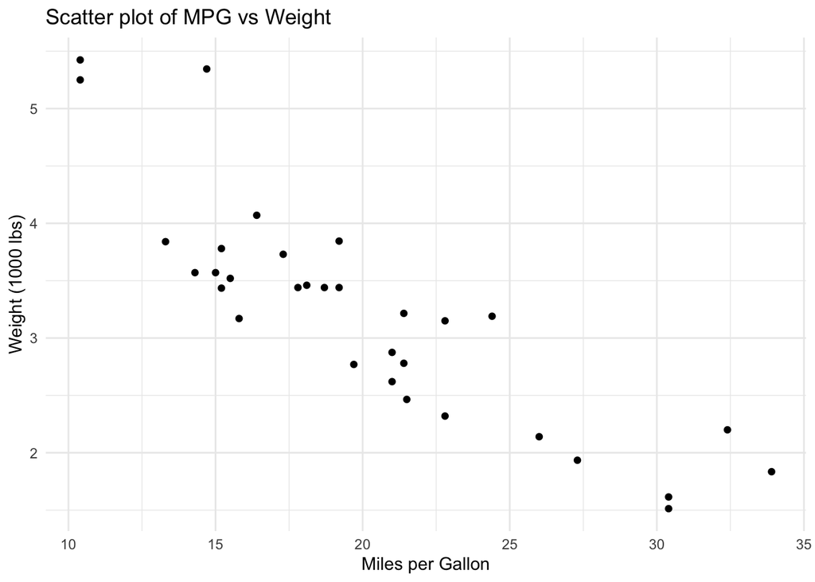

```r
ggplot(mtcars, aes(x = mpg, y = wt)) +
  geom_point() +
  theme_minimal() +
  labs(title = "Scatter plot of MPG vs Weight",
       x = "Miles per Gallon",
       y = "Weight (1000 lbs)")
```

# Tables

You can create tables using the `knitr::kable()` function:

```r
library(knitr)
kable(head(mtcars), caption = "First 6 rows of the mtcars dataset")
```

First 6 rows of the mtcars dataset

|  | mpg | cyl | disp | hp | drat | wt | qsec | vs | am | gear | carb |
| --- | --- | --- | --- | --- | --- | --- | --- | --- | --- | --- | --- |
| Mazda RX4 | 21.0 | 6 | 160 | 110 | 3.90 | 2.620 | 16.46 | 0 | 1 | 4 | 4 |
| Mazda RX4 Wag | 21.0 | 6 | 160 | 110 | 3.90 | 2.875 | 17.02 | 0 | 1 | 4 | 4 |
| Datsun 710 | 22.8 | 4 | 108 | 93 | 3.85 | 2.320 | 18.61 | 1 | 1 | 4 | 1 |
| Hornet 4 Drive | 21.4 | 6 | 258 | 110 | 3.08 | 3.215 | 19.44 | 1 | 0 | 3 | 1 |
| Hornet Sportabout | 18.7 | 8 | 360 | 175 | 3.15 | 3.440 | 17.02 | 0 | 0 | 3 | 2 |
| Valiant | 18.1 | 6 | 225 | 105 | 2.76 | 3.460 | 20.22 | 1 | 0 | 3 | 1 |

# Conclusion

Save this file with the `.Rmd` extension and use the `rmarkdown::render()` function in R to generate an output document.